# (Ford GoBike Trip Data Analysis)

## Investigation Overview

The goal is to figure out why the service subscribers have shorter ride durations than customers.

## Dataset Overview

The dataset describes the rides made by the users of Ford GoBike service in February 2019.

```python
# import all packages and set plots to be embedded inline
import numpy as np
import pandas as pd
import matplotlib.pyplot as plt
import seaborn as sb

%matplotlib inline

# suppress warnings from final output
import warnings
warnings.simplefilter("ignore")
```

```python
# load in the dataset into a pandas dataframe
df = pd.read_csv("fordgobike-tripdata.csv")


# correct Dtype for start_time and end_time
df['start_time'] = pd.to_datetime(df['start_time'])
df['end_time'] = pd.to_datetime(df['end_time'])

# drop missing values
df.dropna(inplace=True)

# age instead of year of birth
df['member_age'] = 2019 - df['member_birth_year'] # 2019 as the data was collected in 2019
df.drop('member_birth_year', axis=1, inplace=True)

# minutes instead of seconds
df['duration_min'] = df['duration_sec'] / 60
df.drop('duration_sec', axis=1, inplace=True)

# ids to int
df['start_station_id'] = df['start_station_id'].astype(int)
df['end_station_id'] = df['end_station_id'].astype(int)


# drop the features I won't be using
drop_features = ['bike_id', 'end_station_latitude', 'start_station_latitude', 'end_station_longitude', 'start_station_longitude']
df.drop(drop_features, axis=1, inplace=True)
```

## Members Type Distribution

The Majority of the rides are made by subscribers to the service.

- These are the people that use the service regularly.
- Customers are the people that use it occasionally.

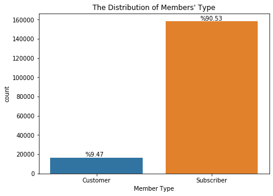

```python
# user type distribution
plt.figure(figsize=(7, 5))
ax = sb.countplot(data=df, x='user_type')
plt.title("The Distribution of Members' Type")
for p in ax.patches:
        ax.annotate('%{:.2f}'.format(p.get_height() / df.shape[0] * 100), (p.get_x()+0.3, p.get_height()+1000))

plt.xlabel("Member Type")
plt.show()
```

## Durations for User Types

Most subscribers have shorter ride durations than customers, but why?

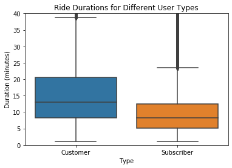

```python
sb.boxplot(data=df, x='user_type', y='duration_min')
plt.ylim((0, 40))
plt.xlabel("Type")
plt.title("Ride Durations for Different User Types")
plt.ylabel("Duration (minutes)")
plt.show()
```

## Stations with the most traffic

First, lets have a look at the stations with the most traffic as a start for a ride and as an end for a ride. You notice something !

- The stations that have high number of rides starting at it also have high nubmber of rides ending at it.
- Yes you are right !! People maybe taking another ride to the starting stations again mabye later in the day :).

```python
top_10_starting_ids = df['start_station_id'].value_counts().reset_index()[:10]['index'].values
top_10_starting = df[df['start_station_id'].isin(top_10_starting_ids)]
top_10_starting_order = top_10_starting.start_station_name.value_counts().index

top_10_ending_ids = df['end_station_id'].value_counts().reset_index()[:10]['index'].values
top_10_ending = df[df['end_station_id'].isin(top_10_ending_ids)]
top_10_ending_order = top_10_ending.end_station_name.value_counts().index
```

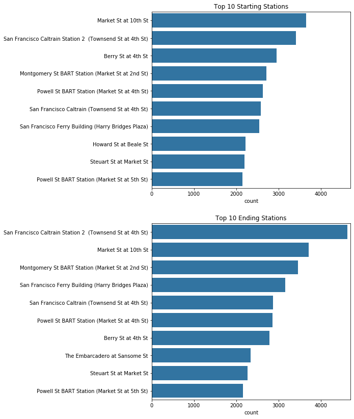

```python
color = sb.color_palette()[0]
plt.figure(figsize=(7, 14))
plt.subplot(2, 1, 1)
plt.title("Top 10 Starting Stations")
sb.countplot(data=top_10_starting, y='start_station_name', color=color, order=top_10_starting_order)
plt.ylabel(None)
plt.xlim((0, 4700))


plt.subplot(2, 1, 2)
plt.title("Top 10 Ending Stations")
sb.countplot(data=top_10_ending , y='end_station_name', color=color, order=top_10_ending_order)
plt.ylabel(None)
plt.xlim((0, 4700))
plt.show()
```

## Why does people return to the starting stations again? 🧐

When we look at the number of rides made on each hour of the day we notice that the hours with the most traffic are 8 and 17.

Yupp!!! 👌 these are the hours where people commute to and come back from work. now we know why they return to the starting station.

```python
df['start_hour'] = df['start_time'].dt.hour
df['start_day'] = df['start_time'].dt.day
df['start_day_name'] = df['start_time'].dt.day_name()
```

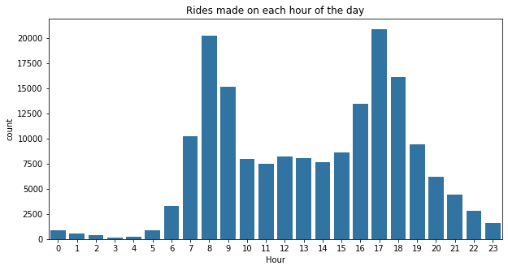

```python
plt.figure(figsize=(10, 5))
sb.countplot(data=df, x='start_hour', color=color)
plt.title("Rides made on each hour of the day")
plt.xlabel("Hour")
plt.show()
```

## Does different type of users use the service the same way?

We saw that most of the rides are related to going to and coming back from work.

But we also know that these numbers are biased because we have way more subscribers than customers. So let's check each of them seperately.

### What does different types of users use the service for?

On the right:

- Subscribers follow the trend with highest points at 8 and 17.
- But during working hours the number of rides is very low relative to the peaks which indicates that most of the subscribers are at work.

On the left:

- Customers follow the same trend for the peak hours.
- But for the hours between the peaks, the number of rides is still relatively high, which suggests that more customers are taking rides on different hours of the day.

This can tell us that customers don't take rides for fixed commutes only but they take it for varies reasons which maybe just occasional and not fixed commitments as the case for subscribers.

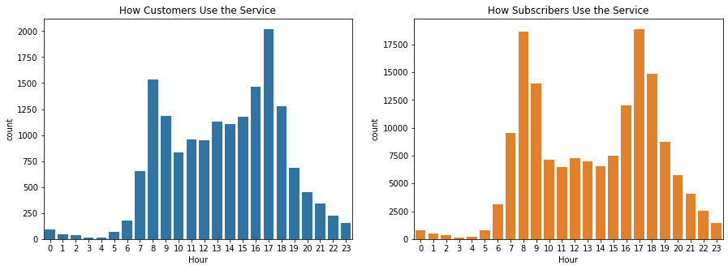

```python
plt.figure(figsize=(15, 5))
ax = plt.subplot(1, 2, 1)
plt.title("How Customers Use the Service")
sb.countplot(data=df[df['user_type'] == 'Customer'], x='start_hour', hue='user_type')
ax.get_legend().remove()
plt.xlabel("Hour")

ax = plt.subplot(1, 2, 2)
plt.title("How Subscribers Use the Service")
sb.countplot(data=df[df['user_type'] == 'Subscriber'], x='start_hour', hue='user_type', palette={"C1"})
ax.get_legend().remove()
plt.xlabel("Hour")
plt.show()
```

## Subsribers are consistant but Customers aren't ! 🧐

As we saw earlier the rides for customers doesn't exactly follow a consistant trend. Some customers may use the service to go to work once someday and others use it for varies different reasons during the day.

Let's see how subscribers and users use the service during the week days:

On the right:

- We have more rides on weekdays and we see the dip on weekends which support our claim that most subscribers use the service to go to and come back from work.

On the left:

- Here, it is totally different, the distribution of rides is very similar between days and weekends which means
  - Customers use the service for many other things than commuting.
  - These things varies from one customer and even for the same customer.

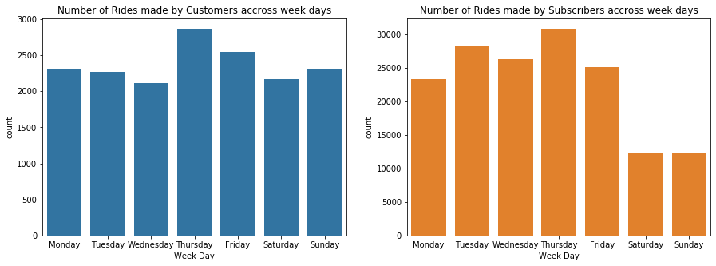

```python
days_order = ['Monday', 'Tuesday', 'Wednesday', 'Thursday', 'Friday', 'Saturday', 'Sunday']
plt.figure(figsize=(15, 5))
ax = plt.subplot(1, 2, 1)
plt.title("Number of Rides made by Customers accross week days")
sb.countplot(data=df[df['user_type'] == 'Customer'], x='start_day_name', hue='user_type', order=days_order)
ax.get_legend().remove()
plt.xlabel("Week Day")

ax = plt.subplot(1, 2, 2)
plt.title("Number of Rides made by Subscribers accross week days")
sb.countplot(data=df[df['user_type'] == 'Subscriber'], x='start_day_name', hue='user_type', order=days_order,
             palette={"C1"})
ax.get_legend().remove()
plt.xlabel("Week Day")
plt.show()
```

## Consistant Makes Shorter

As subscribers are more consistant with their rides. They are more likey to know the roads and routs and maybe some shortcuts😉. This can help them ride the same commute in shorter periods than customers.

Customers are not consistant and their rides maybe totaly knew to them each time as they use the service occasionally for different trips which means new roads, new routes and no shortcuts 😔. This could lead them to having longer rides.